# Análise Exploratória de Dados

Luiz Carlos Castro Cunha Junior

29/05/2021

[figure not shown]

## Estudo de Caso: Imóveis

De acordo com a localização de um imóvel, sabe-se que o valor do mesmo pode variar substancialmente. Na base de dados disponibilizada são fornecidas informações sobre o valor do imóvel (R$ mil) por m2, a distância para estação de metrô (km), a idade e a região.

- Faça a distribuição de frequências da variável idade.
- Faça a distribuição de frequências da variável região.
- Qual o valor do mínimo, máximo, mediana, Q1 e Q3 da variável distância ao metrô? Interprete os valores.
- Qual o valor do mínimo, máximo, mediana, Q1 e Q3 da variável valor do imóvel (R$ mil) por m²? Interprete os valores.

### Carregando os pacotes a serem utilizados

```r
library(tidyverse)
library(readxl)
library(rstatix)
library(moments)
library(knitr)
library(rmarkdown)
library(kableExtra)
library(emmeans)
library(htmltools)
library(dplyr)
library(questionr)
```

### Importando o Conjunto de Dados

```r
dataset<-readxl::read_xlsx("Exercícios.xlsx",
                           sheet = "Base de Dados 3")
```

### Visualizando o tipo de dados das variáveis

```r
str(dataset)
```

```
## tibble [413 x 5] (S3: tbl_df/tbl/data.frame)
##  $ Id_Imovel         : num [1:413] 1 2 3 4 5 6 7 8 9 10 ...
##  $ Idade_imovel      : chr [1:413] "3. Acima de 25 anos" "2. 10 a 25 anos" "2. 10 a 25 anos" "2. 10 a 25 anos" ...
##  $ Região            : chr [1:413] "Norte" "Sul" "Sul" "Norte" ...
##  $ Distancia_metro_Km: num [1:413] 1.08 1.4 1.54 1.54 1.46 ...
##  $ Mil_reais_m2      : num [1:413] 7.58 8.44 9.46 10.96 8.62 ...
```

### Visualizando as primeiras linhas do Dataset

```r
kbl(dataset[1:5,2:5]) %>%
  kable_paper()
```

Idade_imovel

Região

Distancia_metro_Km

Mil_reais_m2

3. Acima de 25 anos

Norte

1.083595

7.58

2. 10 a 25 anos

Sul

1.396946

8.44

2. 10 a 25 anos

Sul

1.544789

9.46

2. 10 a 25 anos

Norte

1.544789

10.96

1. Até 10 anos

Norte

1.456010

8.62

### Perguntas de Negócio

> Faça a distribuição de frequências da variável idade.

```r
dfFrequenciaIdade <- questionr::freq(dataset$Idade_imovel, total = TRUE)
colnames(dfFrequenciaIdade) <- c("Frequência Absoluta", "Frequência Relativa")

kbl(dfFrequenciaIdade[, 1:2]) %>%
  kable_paper()
```

Frequência Absoluta

Frequência Relativa

1. Até 10 anos

109

26.4

2. 10 a 25 anos

187

45.3

3. Acima de 25 anos

117

28.3

Total

413

100.0

> Faça a distribuição de frequências da variável região.

```r
dfFrequenciaIdade <- questionr::freq(dataset$Região, total = TRUE)
colnames(dfFrequenciaIdade) <- c("Frequência Absoluta", "Frequência Relativa")

kbl(dfFrequenciaIdade[, 1:2]) %>%
  kable_paper()
```

|  | Frequência Absoluta | Frequência Relativa |
| --- | --- | --- |
| Norte | 155 | 37.5 |
| Sul | 258 | 62.5 |
| Total | 413 | 100.0 |

> Qual o valor do mínimo, máximo, mediana, Q1 e Q3 da variável distância ao metrô? Interprete os valores.

Podemos observar que a localização dos imóveis estão variando aproximadamente 1.3 KM de distância em relação ao metrô.

|  | Valores |
| --- | --- |
| Minimo | 0.7690434 |
| Máximo | 2.1416361 |
| Média | 1.5599941 |
| Mediana | 1.5124546 |
| PrimeiroQuartil | 1.3828009 |
| SegundoQuartil | 1.5124546 |
| TerceiroQuartil | 1.7770231 |
| Amplitude | 1.3725927 |
| LimiteInferior | 0.7914677 |
| IntervaloInterQuartil | 0.3942222 |

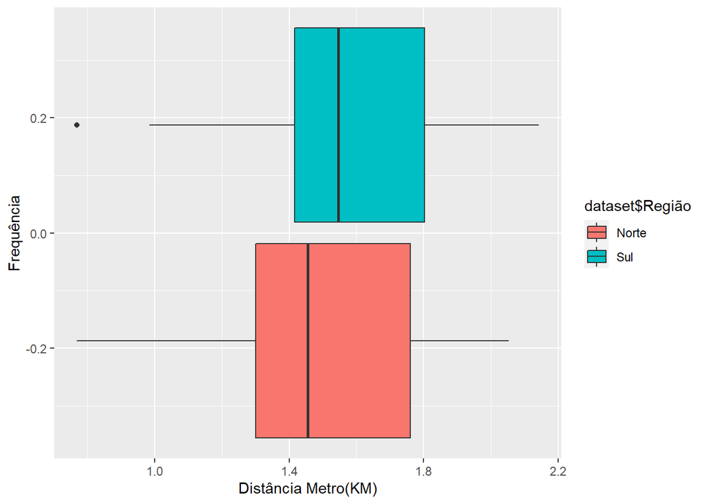

```r
dataset %>%
  ggplot(aes(dataset$Distancia_metro_Km, fill = dataset$Região)) +
  geom_boxplot(bins = 30)+
  xlab("Distância Metro(KM)")+
  ylab("Frequência")
```

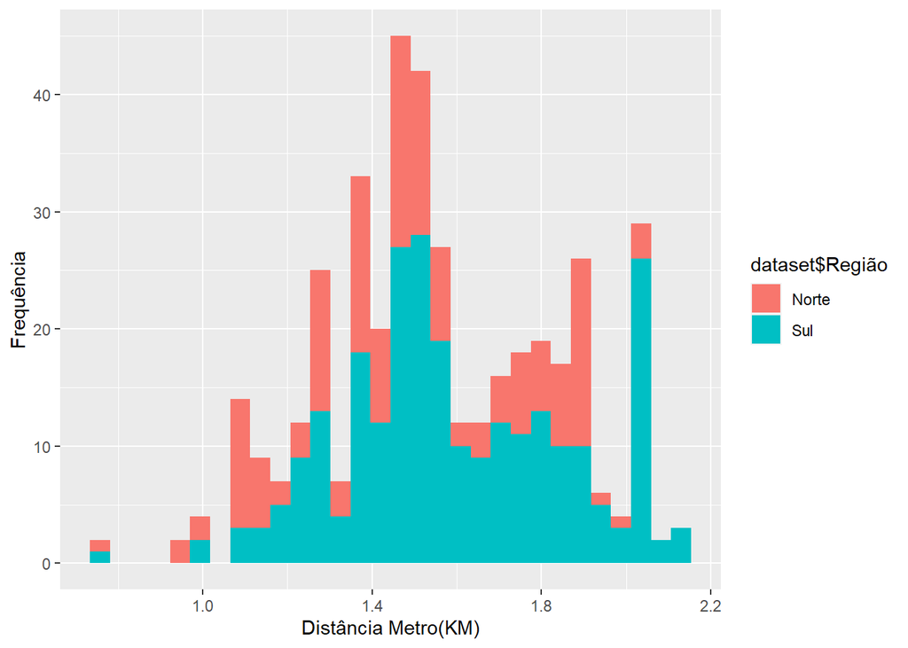

```r
dataset %>%
  ggplot(aes(dataset$Distancia_metro_Km, fill = dataset$Região)) +
  geom_histogram(bins = 30)+
  xlab("Distância Metro(KM)")+
  ylab("Frequência")
```

> Qual o valor do mínimo, máximo, mediana, Q1 e Q3 da variável valor do imóvel (R$ mil) por m²? Interprete os valores.

De acordo com os valores apresentados abaixo podemos observar que o valor dos imóveis estão variando a aproxidamente R$ 14.140,00.

Sendo que o imóvel mais barato está custando R$ 1.520,00 e o mais caro R$ 15.660,00

|  | Valores |
| --- | --- |
| Minimo | 1.52000 |
| Máximo | 15.66000 |
| Média | 7.55753 |
| Mediana | 7.68000 |
| PrimeiroQuartil | 5.54000 |
| SegundoQuartil | 7.68000 |
| TerceiroQuartil | 9.32000 |
| Amplitude | 14.14000 |
| LimiteInferior | -0.13000 |
| IntervaloInterQuartil | 3.78000 |

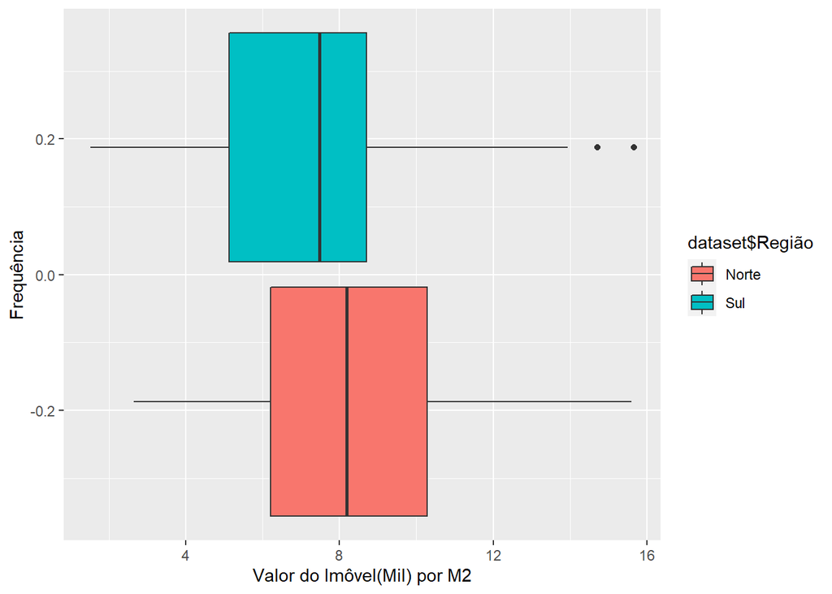

```r
dataset %>%
  ggplot(aes(dataset$Mil_reais_m2, fill = dataset$Região)) +
  geom_boxplot(bins = 30)+
  xlab("Valor do Imôvel(Mil) por M2")+
  ylab("Frequência")
```

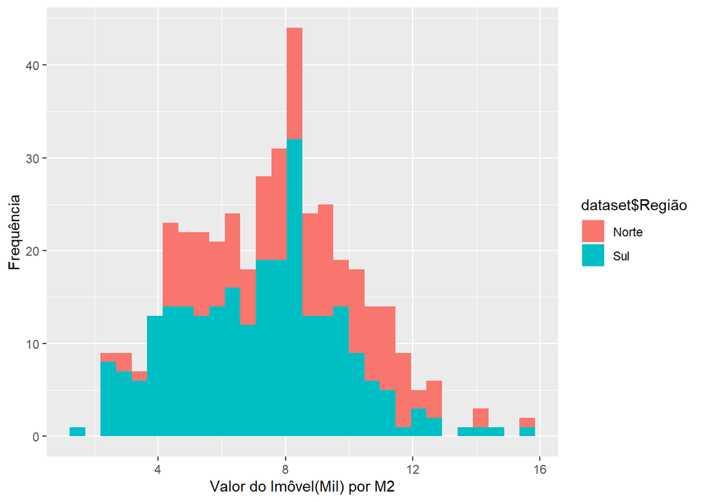

```r
dataset %>%
  ggplot(aes(dataset$Mil_reais_m2, fill = dataset$Região)) +
  geom_histogram(bins = 30)+
  xlab("Valor do Imôvel(Mil) por M2")+
  ylab("Frequência")
```